# Age_analysis

Holly Hake

2024-10-15

```r
# Plot theme
library(wesanderson)

theme_set(theme_light(base_size = 14) +
            theme(strip.text = element_text(colour = "black")))

condition_colours <- wes_palette("Darjeeling1", n = 5)
condition_colours[c(2, 4, 5)] <- condition_colours[c(4, 5, 2)]

dataset_colours <- wes_palette("Darjeeling2", n = 5)[c(2, 3)]
```

```r
# Load data
load("cleandata_all.RData")
load("cleandata_avg_all.RData")
load("cleandata_avg_allreactable1.RData")
```

```r
# Clean and prepare data for analysis

# Create a factor for paired userId in cleandata_avg_allreactable1
cleandata_avg_allreactable1 <- cleandata_avg_allreactable1 %>%
  mutate(paired = factor(userId))

# Remove specific categories and subtypes from cleandata_avg_allreactable1
cleandata_avg_allreactable1 <- cleandata_avg_allreactable1 %>%
  filter(!category %in% c("Family", "Friend")) %>%
  filter(!name_or_subtype %in% c("stoccofam01"))

# Remove specific subtypes from cleandata_avg_all
cleandata_avg_all <- cleandata_avg_all %>%
  filter(!name_or_subtype %in% c("Anon", "stoccofam01"))

# Omit NA values from both datasets
cleandata_avg_all <- na.omit(cleandata_avg_all)
cleandata_avg_allreactable1 <- na.omit(cleandata_avg_allreactable1)
```

```r
# Define age category conditions for cleandata_avg_allreactable1
cleandata_avg_allreactable1 <- cleandata_avg_allreactable1 %>%
  mutate(category2 = case_when(
    age == 5 ~ "Early Childhood (5)",
    age >= 6 & age <= 12 ~ "Middle and Late Childhood (6-12)",
    age >= 13 & age <= 17 ~ "Adolescence (13-17)",
    age >= 18 & age <= 29 ~ "Early Adulthood (18-29)",
    age >= 30 & age <= 45 ~ "Middle Adulthood (30-45)",
    age >= 46 & age <= 64 ~ "Mature Adulthood (46-64)",
    age >= 65 ~ "Senior Adulthood (65+)"
  ))

# Define additional age category conditions for "Senior MCI"
cleandata_avg_allreactable1 <- cleandata_avg_allreactable1 %>%
  mutate(category3 = case_when(
    category2 == "Mature Adulthood (46-64)" & category == "Senior MCI" ~ "Mature Adulthood (46-64, Impaired)",
    category2 == "Senior Adulthood (65+)" & category == "Senior MCI" ~ "Senior Impaired (65+)",
    TRUE ~ category2  # Retain original category if conditions are not met
  ))

# Define additional conditions for "Senior PreAD" in category3
cleandata_avg_allreactable1 <- cleandata_avg_allreactable1 %>%
  mutate(category3 = case_when(
    category == "Senior PreAD" & age >= 46 & age <= 64 ~ "Mature Adulthood (46-64, Early Onset AD)",
    TRUE ~ category3  # Retain original category if conditions are not met
  ))

# Convert category3 to a factor with specified levels
cleandata_avg_allreactable1$category3 <- factor(cleandata_avg_allreactable1$category3,
  levels = c("Early Childhood (5)",
             "Middle and Late Childhood (6-12)",
             "Adolescence (13-17)",
             "Early Adulthood (18-29)",
             "Middle Adulthood (30-45)",
             "Mature Adulthood (46-64)",
             "Mature Adulthood (46-64, Impaired)",
             "Mature Adulthood (46-64, Early Onset AD)",
             "Senior Adulthood (65+)",
             "Senior Impaired (65+)")
)

# Define age category conditions for cleandata_avg_all
cleandata_avg_all <- cleandata_avg_all %>%
  mutate(category2 = case_when(
    age == 5 ~ "Early Childhood (5)",
    age >= 6 & age <= 12 ~ "Middle and Late Childhood (6-12)",
    age >= 13 & age <= 17 ~ "Adolescence (13-17)",
    age >= 18 & age <= 29 ~ "Early Adulthood (18-29)",
    age >= 30 & age <= 45 ~ "Middle Adulthood (30-45)",
    age >= 46 & age <= 64 ~ "Mature Adulthood (46-64)",
    age >= 65 ~ "Senior Adulthood (65+)"
  ))

# Define additional age category conditions for "Senior MCI" in cleandata_avg_all
cleandata_avg_all <- cleandata_avg_all %>%
  mutate(category3 = case_when(
    category2 == "Mature Adulthood (46-64)" & category == "Senior MCI" ~ "Mature Adulthood (46-64, Impaired)",
    category2 == "Senior Adulthood (65+)" & category == "Senior MCI" ~ "Senior Impaired (65+)",
    TRUE ~ category2  # Retain original category if conditions are not met
  ))

# Define additional conditions for "Senior PreAD" in category3
cleandata_avg_all <- cleandata_avg_all %>%
  mutate(category3 = case_when(
    category == "Senior PreAD" & age >= 46 & age <= 64 ~ "Mature Adulthood (46-64, Early Onset AD)",
    TRUE ~ category3  # Retain original category if conditions are not met
  ))

# Convert category3 to a factor with specified levels for cleandata_avg_all
cleandata_avg_all$category3 <- factor(cleandata_avg_all$category3,
  levels = c("Early Childhood (5)",
             "Middle and Late Childhood (6-12)",
             "Adolescence (13-17)",
             "Early Adulthood (18-29)",
             "Middle Adulthood (30-45)",
             "Mature Adulthood (46-64)",
             "Mature Adulthood (46-64, Impaired)",
             "Mature Adulthood (46-64, Early Onset AD)",
             "Senior Adulthood (65+)",
             "Senior Impaired (65+)")
)

# Remove the n=1 for specific groups in cleandata_avg_allreactable1
cleandata_avg_allreactable1 <- cleandata_avg_allreactable1 %>%
  filter(!category3 %in% c("Mature Adulthood (46-64, Impaired)",
                            "Mature Adulthood (46-64, Early Onset AD)"))

# Remove the n=1 for specific groups in cleandata_avg_all
cleandata_avg_all <- cleandata_avg_all %>%
  filter(!category3 %in% c("Mature Adulthood (46-64, Impaired)",
                            "Mature Adulthood (46-64, Early Onset AD)"))
```

## Age Counts

```r
# Create a table with counts of each age grouped by category3
age_counts <- cleandata_avg_allreactable1 %>%
  group_by(age, category3) %>%
  summarise(n = n(), .groups = "drop")  # Drop grouping for subsequent operations

# Create a table with counts of each age group (category3)
agegroup_counts <- cleandata_avg_allreactable1 %>%
  group_by(category3) %>%
  summarise(n = n(), .groups = "drop")  # Drop grouping for subsequent operations
```

```r
# Print the age counts table
age_counts %>%
  kable(caption = "Counts of Each Age", col.names = c("Age", "Group", "N"), format = "html") %>%
  kable_styling(bootstrap_options = c("hover", "striped")) %>%
  column_spec(1, width = "200px") %>% # Set a fixed width for the first column
  kable_styling(latex_options = c("hold_position")) # Optional: hold position in LaTeX
```

Counts of Each Age

| Age | Group | N |
| --- | --- | --- |
| 5 | Early Childhood (5) | 17 |
| 16 | Adolescence (13-17) | 2 |
| 17 | Adolescence (13-17) | 1 |
| 18 | Early Adulthood (18-29) | 43 |
| 19 | Early Adulthood (18-29) | 33 |
| 20 | Early Adulthood (18-29) | 17 |
| 21 | Early Adulthood (18-29) | 20 |
| 22 | Early Adulthood (18-29) | 6 |
| 23 | Early Adulthood (18-29) | 3 |
| 24 | Early Adulthood (18-29) | 2 |
| 25 | Early Adulthood (18-29) | 2 |
| 26 | Early Adulthood (18-29) | 1 |
| 27 | Early Adulthood (18-29) | 2 |
| 28 | Early Adulthood (18-29) | 2 |
| 29 | Early Adulthood (18-29) | 2 |
| 30 | Middle Adulthood (30-45) | 2 |
| 31 | Middle Adulthood (30-45) | 3 |
| 32 | Middle Adulthood (30-45) | 5 |
| 33 | Middle Adulthood (30-45) | 1 |
| 34 | Middle Adulthood (30-45) | 1 |
| 35 | Middle Adulthood (30-45) | 3 |
| 36 | Middle Adulthood (30-45) | 3 |
| 37 | Middle Adulthood (30-45) | 5 |
| 38 | Middle Adulthood (30-45) | 3 |
| 39 | Middle Adulthood (30-45) | 6 |
| 40 | Middle Adulthood (30-45) | 4 |
| 41 | Middle Adulthood (30-45) | 3 |
| 42 | Middle Adulthood (30-45) | 2 |
| 43 | Middle Adulthood (30-45) | 3 |
| 44 | Middle Adulthood (30-45) | 1 |
| 45 | Middle Adulthood (30-45) | 5 |
| 46 | Mature Adulthood (46-64) | 1 |
| 47 | Mature Adulthood (46-64) | 1 |
| 48 | Mature Adulthood (46-64) | 2 |
| 49 | Mature Adulthood (46-64) | 3 |
| 50 | Mature Adulthood (46-64) | 1 |
| 51 | Mature Adulthood (46-64) | 2 |
| 52 | Mature Adulthood (46-64) | 4 |
| 53 | Mature Adulthood (46-64) | 1 |
| 54 | Mature Adulthood (46-64) | 2 |
| 55 | Mature Adulthood (46-64) | 2 |
| 57 | Mature Adulthood (46-64) | 2 |
| 58 | Mature Adulthood (46-64) | 5 |
| 59 | Mature Adulthood (46-64) | 3 |
| 60 | Mature Adulthood (46-64) | 5 |
| 61 | Mature Adulthood (46-64) | 4 |
| 62 | Mature Adulthood (46-64) | 8 |
| 63 | Mature Adulthood (46-64) | 4 |
| 64 | Mature Adulthood (46-64) | 3 |
| 65 | Senior Adulthood (65+) | 2 |
| 66 | Senior Adulthood (65+) | 2 |
| 68 | Senior Impaired (65+) | 1 |
| 69 | Senior Adulthood (65+) | 2 |
| 69 | Senior Impaired (65+) | 1 |
| 70 | Senior Adulthood (65+) | 1 |
| 70 | Senior Impaired (65+) | 2 |
| 71 | Senior Adulthood (65+) | 1 |
| 71 | Senior Impaired (65+) | 5 |
| 72 | Senior Adulthood (65+) | 5 |
| 73 | Senior Adulthood (65+) | 4 |
| 73 | Senior Impaired (65+) | 1 |
| 74 | Senior Adulthood (65+) | 1 |
| 74 | Senior Impaired (65+) | 1 |
| 75 | Senior Adulthood (65+) | 1 |
| 75 | Senior Impaired (65+) | 1 |
| 76 | Senior Impaired (65+) | 1 |
| 77 | Senior Adulthood (65+) | 1 |
| 78 | Senior Adulthood (65+) | 2 |
| 79 | Senior Impaired (65+) | 2 |
| 80 | Senior Impaired (65+) | 2 |
| 82 | Senior Adulthood (65+) | 1 |
| 82 | Senior Impaired (65+) | 1 |
| 83 | Senior Adulthood (65+) | 1 |
| 84 | Senior Adulthood (65+) | 1 |

```r
# Print the age group counts table
agegroup_counts %>%
  kable(caption = "Counts of Each Age Group", col.names = c("Age Group", "N")) %>%
  kable_styling(bootstrap_options = c("hover", "striped"))
```

Counts of Each Age Group

| Age Group | N |
| --- | --- |
| Early Childhood (5) | 17 |
| Adolescence (13-17) | 3 |
| Early Adulthood (18-29) | 133 |
| Middle Adulthood (30-45) | 50 |
| Mature Adulthood (46-64) | 53 |
| Senior Adulthood (65+) | 25 |
| Senior Impaired (65+) | 18 |

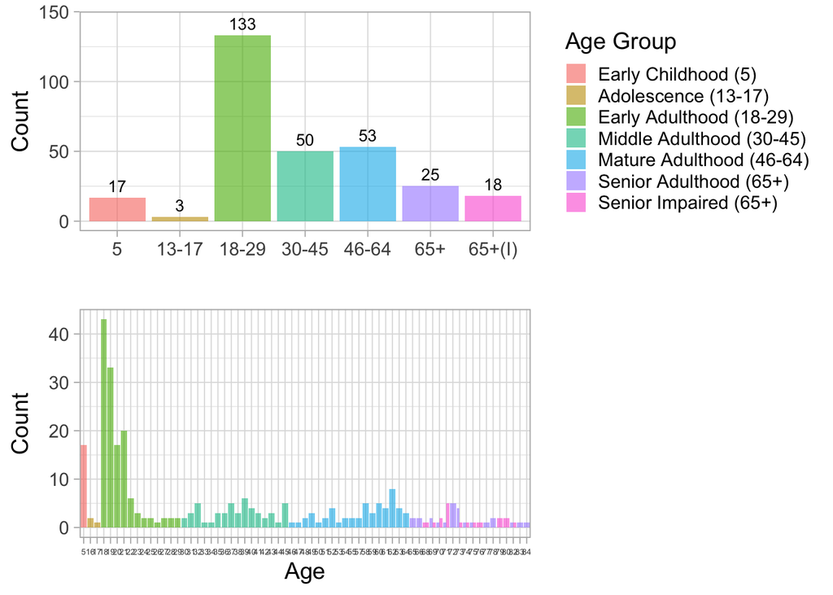

```r
# Convert category3 to a factor with defined levels for consistent plotting
age_counts$category3 <- factor(age_counts$category3,
  levels = c("Early Childhood (5)",
             "Middle and Late Childhood (6-12)",
             "Adolescence (13-17)",
             "Early Adulthood (18-29)",
             "Middle Adulthood (30-45)",
             "Mature Adulthood (46-64)",
             "Mature Adulthood (46-64, Impaired)",
             "Mature Adulthood (46-64, Early Onset AD)",
             "Senior Adulthood (65+)",
             "Senior Impaired (65+)"))

# Create a bar plot for age group counts
agegroups <- ggplot(agegroup_counts, aes(x = category3, y = n, fill = category3)) +
  geom_bar(stat = "identity", position = "dodge", alpha = 0.6) +
  geom_text(aes(label = n),  # Add the count labels on the bars
            position = position_dodge(width = 0.9),  # Adjust position to dodge correctly
            vjust = -0.5,  # Vertical adjustment (above the bars)
            size = 3.5) +  # Size of the text
  xlab(" ") +
  ylab("Count") +
  labs(fill = "Age Group", color = "Age Group") +
  theme(
    legend.position = "right",
    legend.key.size = unit(0.9, "lines")
  ) +
  scale_x_discrete(labels = c(
    "Early Childhood (5)" = "5",
    "Middle and Late Childhood (6-12)" = "6-12",
    "Adolescence (13-17)" = "13-17",
    "Early Adulthood (18-29)" = "18-29",
    "Middle Adulthood (30-45)" = "30-45",
    "Mature Adulthood (46-64)" = "46-64",
    "Mature Adulthood (46-64, Impaired)" = "46-64(I)",
    "Mature Adulthood (46-64, Early Onset AD)" = "46-64(AD)",
    "Senior Adulthood (65+)" = "65+",
    "Senior Impaired (65+)" = "65+(I)"
  )) +
  ylim(0, max(agegroup_counts$n) + 10)

# Create a bar plot for age counts
allages <- ggplot(age_counts, aes(x = factor(age), y = n, fill = category3)) +
  geom_bar(stat = "identity", position = "dodge", alpha = 0.6) +
  xlab("Age") +
  ylab("Count") +
  labs(fill = "Age Group", color = "Age Group") +
  theme(
    legend.position = "none",  # Hide the legend for this plot
    legend.key.size = unit(0.9, "lines"),
    axis.text.x = element_text(size = 5)
  )

# Combine plots using cowplot
datacollection_agecount <- cowplot::plot_grid(
  agegroups,
  allages,
  ncol = 1,
  rel_heights = c(1, 1),
  align = "v"
)

# Save the combined plot as a PNG file
ggsave("figures/datacollection_agecount.png", datacollection_agecount)

datacollection_agecount
```

## Age Measures

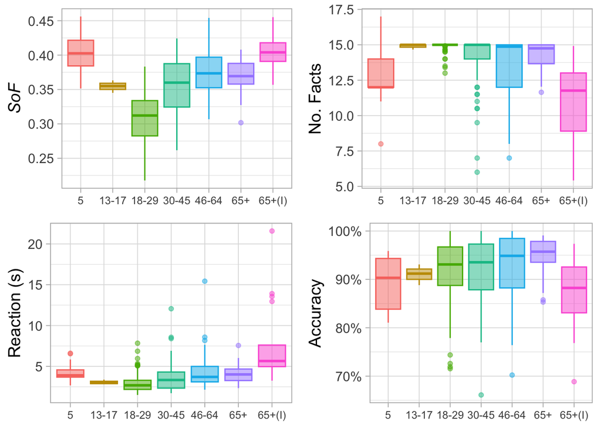

```r
# Create boxplot for TotalMeanAlpha
p1 <- ggplot(cleandata_avg_allreactable1, aes(x = category3, y = TotalMeanAlpha, color = category3, fill = category3)) +
  geom_boxplot(size = 0.5, width = 0.8, alpha = 0.5) +
  xlab("Age Group") +
  ylab(expression(paste(italic("SoF")))) +
  labs(fill = "Age Group", color = "Age Group") +
  theme(
    legend.position = "hide",
    axis.title.x = element_blank(),
    axis.text.x = element_text(size = 9)
  ) +
  scale_x_discrete(labels = c(
    "Early Childhood (5)" = "5",
    "Middle and Late Childhood (6-12)" = "6-12",
    "Adolescence (13-17)" = "13-17",
    "Early Adulthood (18-29)" = "18-29",
    "Middle Adulthood (30-45)" = "30-45",
    "Mature Adulthood (46-64)" = "46-64",
    "Senior Adulthood (65+)" = "65+",
    "Senior Impaired (65+)" = "65+(I)"
  ))

# Create boxplot for TotalMeanFactAvg
p2 <- ggplot(cleandata_avg_allreactable1, aes(x = category3, y = TotalMeanFactAvg, color = category3, fill = category3)) +
  geom_boxplot(size = 0.5, width = 0.8, alpha = 0.5) +
  xlab("Age Group") +
  ylab("No. Facts") +
  labs(fill = "Age Group", color = "Age Group") +
  theme(
    legend.position = "hide",
    axis.title.x = element_blank(),
    axis.text.x = element_text(size = 9)
  ) +
  scale_x_discrete(labels = c(
    "Early Childhood (5)" = "5",
    "Middle and Late Childhood (6-12)" = "6-12",
    "Adolescence (13-17)" = "13-17",
    "Early Adulthood (18-29)" = "18-29",
    "Middle Adulthood (30-45)" = "30-45",
    "Mature Adulthood (46-64)" = "46-64",
    "Senior Adulthood (65+)" = "65+",
    "Senior Impaired (65+)" = "65+(I)"
  ))

# Create boxplot for TotalMeanResponseTime
p3 <- ggplot(cleandata_avg_allreactable1, aes(x = category3, y = TotalMeanResponseTime, color = category3, fill = category3)) +
  geom_boxplot(size = 0.5, width = 0.8, alpha = 0.5) +
  xlab("Age Group") +
  ylab("Reaction (s)") +
  labs(fill = "Age Group", color = "Age Group") +
  theme(
    legend.position = "hide",
    axis.title.x = element_blank(),
    axis.text.x = element_text(size = 9)
  ) +
  scale_x_discrete(labels = c(
    "Early Childhood (5)" = "5",
    "Middle and Late Childhood (6-12)" = "6-12",
    "Adolescence (13-17)" = "13-17",
    "Early Adulthood (18-29)" = "18-29",
    "Middle Adulthood (30-45)" = "30-45",
    "Mature Adulthood (46-64)" = "46-64",
    "Senior Adulthood (65+)" = "65+",
    "Senior Impaired (65+)" = "65+(I)"
  ))

# Create boxplot for TotalMeanAccuracy
p4 <- ggplot(cleandata_avg_allreactable1, aes(x = category3, y = TotalMeanAccuracy, color = category3, fill = category3)) +
  geom_boxplot(size = 0.5, width = 0.8, alpha = 0.5, position = "dodge") +
  scale_x_continuous(breaks = 1:6) +
  scale_y_continuous(labels = scales::percent_format()) +
  xlab("Age Group") +
  ylab("Accuracy") +
  labs(fill = "Age Group", color = "Age Group") +
  theme(
    legend.position = "hide",
    axis.title.x = element_blank(),
    axis.text.x = element_text(size = 9)
  ) +
  scale_x_discrete(labels = c(
    "Early Childhood (5)" = "5",
    "Middle and Late Childhood (6-12)" = "6-12",
    "Adolescence (13-17)" = "13-17",
    "Early Adulthood (18-29)" = "18-29",
    "Middle Adulthood (30-45)" = "30-45",
    "Mature Adulthood (46-64)" = "46-64",
    "Senior Adulthood (65+)" = "65+",
    "Senior Impaired (65+)" = "65+(I)"
  ))

# Combine all plots into one
age_measures <- cowplot::plot_grid(p1, p2, p3, p4)

# Save the combined plot to a file
ggsave("figures/age_measures.png", age_measures)

age_measures
```

```r
# Create a table of the values
mean_alpha_table <- cleandata_avg_allreactable1 %>%
  group_by(category3) %>%
  summarise(
    Mean_TotalMeanAlpha = mean(TotalMeanAlpha, na.rm = TRUE),
    Mean_TotalMeanFactAvg = mean(TotalMeanFactAvg, na.rm = TRUE),
    Mean_TotalMeanResponseTime = mean(TotalMeanResponseTime, na.rm = TRUE),
    Mean_TotalMeanAccuracy = mean(TotalMeanAccuracy, na.rm = TRUE),
    Count_Subjects = n_distinct(userId),  # Count unique subjects
    Total_Lessons = sum(points, na.rm = TRUE)  # Sum points for total lessons
  ) %>%
  arrange(factor(
    category3,
    levels = c(
      "Early Childhood (5)",
      "Middle and Late Childhood (6-12)",
      "Adolescence (13-17)",
      "Early Adulthood (18-29)",
      "Middle Adulthood (30-45)",
      "Mature Adulthood (46-64)",
      "Senior Adulthood (65+)",
      "Senior Impaired (65+)"
    )
  ))

mean_alpha_table %>%
  kable(caption = "Means for Each Age Group", col.names = c("Age Group", "SoF", "No. Facts", "RT(s)", "Acc", "N", "Total Lessons")) %>%
  kable_styling(bootstrap_options = c("hover", "striped"))
```

Means for Each Age Group

| Age Group | SoF | No. Facts | RT(s) | Acc | N | Total Lessons |
| --- | --- | --- | --- | --- | --- | --- |
| Early Childhood (5) | 0.4008356 | 13.00000 | 4.222486 | 0.8898333 | 16 | 17 |
| Adolescence (13-17) | 0.3544861 | 14.88889 | 3.049313 | 0.9103124 | 3 | 26 |
| Early Adulthood (18-29) | 0.3085768 | 14.92782 | 2.898317 | 0.9188319 | 133 | 588 |
| Middle Adulthood (30-45) | 0.3543740 | 13.89000 | 3.764918 | 0.9172821 | 50 | 87 |
| Mature Adulthood (46-64) | 0.3759260 | 13.53130 | 4.351886 | 0.9213504 | 53 | 378 |
| Senior Adulthood (65+) | 0.3692631 | 14.22157 | 4.078873 | 0.9462017 | 25 | 975 |
| Senior Impaired (65+) | 0.4047868 | 10.93339 | 7.672782 | 0.8733538 | 18 | 596 |

```r
# If you would like to save the table as a png...uncomment below

# Print the table using knitr and kableExtra
#mean_alpha_table %>%
#  kable(
#    format = "html",
#    col.names = c("Age Group", "SoF", "No. Facts", "RT(s)", "Acc", "N", "Total Lessons"),
#    caption = "Means for Each Age Group"
#  ) %>%
#  kable_styling(
#    bootstrap_options = c("striped", "hover", "condensed", "responsive"),
#    full_width = FALSE
#  ) %>%
#  save_kable("mean_alpha_table.html")

# Convert the HTML file to PNG with improved quality
# webshot(
#  "mean_alpha_table.html",
#  "figures/mean_alpha_table_image.png",
#  vwidth = 800,  # Adjust this width as needed
#  vheight = 600,  # Adjust this height as needed
#  zoom = 2        # Increase zoom for higher resolution
#)
```

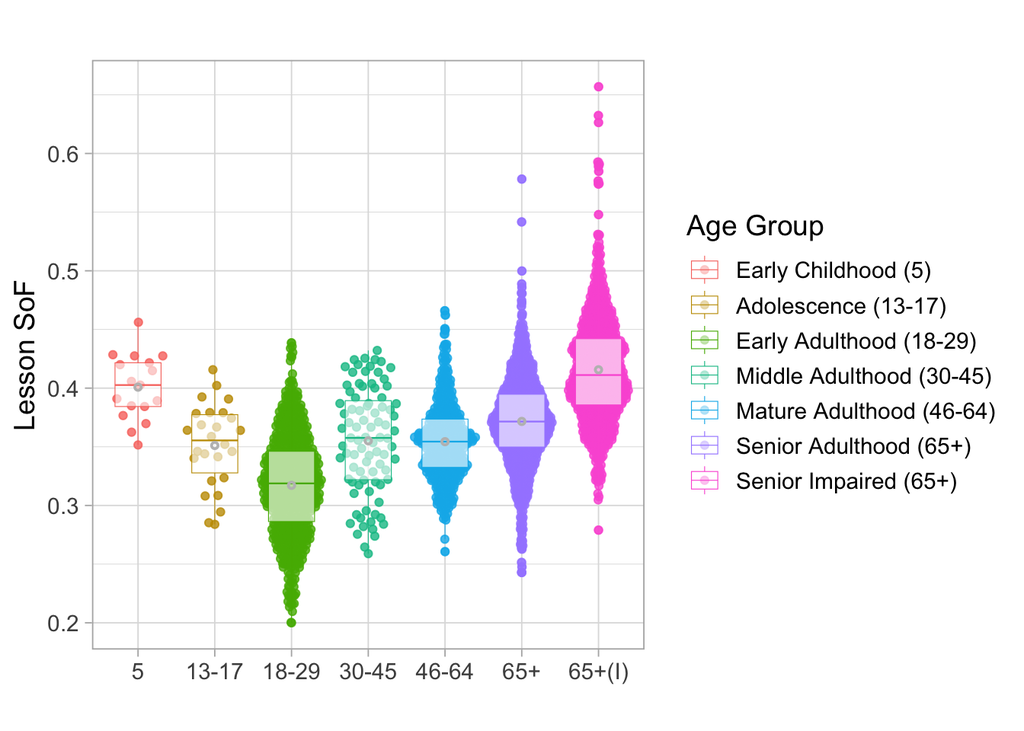

```r
# Create beeswarm Speed of Forgetting (SoF) plot
beeswarm <- ggplot(cleandata_avg_all, aes(x = category3, y = MeanAlpha, color = category3)) +
  geom_quasirandom(alpha = 0.8) +
  geom_boxplot(width = 0.6, size = 0.2, alpha = 0.6) +
  stat_summary(fun = mean, geom = "pointrange", size = 0.2, shape = 1, color = "grey") +
  xlab(" ") +
  ylab("Lesson SoF") +
  ggtitle(" ") +
  labs(col = "Age Group", fill = "Age Group") +
  theme(legend.position = "right") +
  scale_x_discrete(labels = c(
    "Early Childhood (5)" = "5",
    "Middle and Late Childhood (6-12)" = "6-12",
    "Adolescence (13-17)" = "13-17",
    "Early Adulthood (18-29)" = "18-29",
    "Middle Adulthood (30-45)" = "30-45",
    "Mature Adulthood (46-64)" = "46-64",
    "Mature Adulthood (46-64, Impaired)" = "46-64(I)",
    "Mature Adulthood (46-64, Early Onset AD)" = "46-64(AD)",
    "Senior Adulthood (65+)" = "65+",
    "Senior Impaired (65+)" = "65+(I)"
  ))

# Save the beeswarm plot
ggsave("figures/beeswarm.png", beeswarm)

beeswarm
```

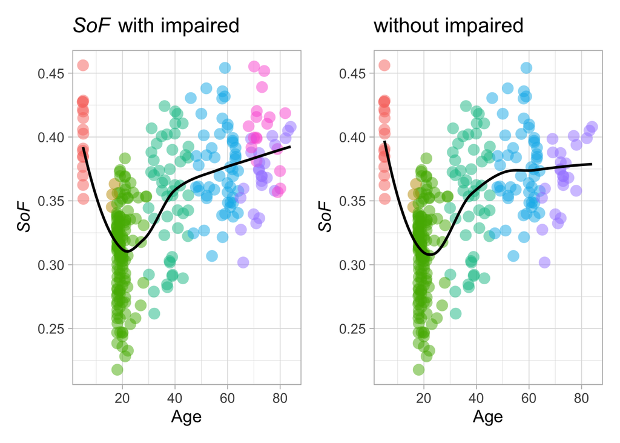

```r
# Create Speed of Forgetting (SoF) plot for all age groups
sof <- ggplot(cleandata_avg_allreactable1, aes(x = age, y = TotalMeanAlpha)) +
  geom_point(aes(color = category3, group = paired), size = 4.5, alpha = 0.5, stroke = 0, position = position_dodge(0.25)) +
  geom_smooth(method = 'loess', se = FALSE, color = 'black', size = 1) +  # Add loess trend line
  xlab("Age") +
  ylab(expression(paste(italic("SoF")))) +
  ggtitle(expression(paste(italic("SoF"), " with impaired"))) +
  labs(col = "Age Group", fill = "Age Group") +
  theme(legend.position = "hide")

# Remove impaired group from data
cleandata_avg_allreactable1_noimp <- cleandata_avg_allreactable1[!cleandata_avg_allreactable1$category3 %in% c("Senior Impaired (65+)"),]

# Create SoF plot without impaired group
sof_noimp <- ggplot(cleandata_avg_allreactable1_noimp, aes(x = age, y = TotalMeanAlpha)) +
  geom_point(aes(color = category3, group = paired), size = 4.5, alpha = 0.5, stroke = 0, position = position_dodge(0.25)) +
  geom_smooth(method = 'loess', se = FALSE, color = 'black', size = 1) +  # Add loess trend line
  scale_color_manual(values = c("#f7766d", "#c39a01", "#54b300", "#00c094", "#02b7eb", "#a58aff", "#fb61d7")) +
  scale_fill_manual(values = c("#f7766d", "#c39a01", "#54b300", "#00c094", "#02b7eb", "#a58aff", "#fb61d7")) +
  xlab("Age") +
  ylab(expression(paste(italic("SoF")))) +
  ggtitle("without impaired") +
  labs(col = "Age Group", fill = "Age Group") +
  theme(legend.position = "none")

# Save the plot
sof_across_age <- cowplot::plot_grid(sof+sof_noimp)
ggsave("figures/sof_across_age.png", sof_across_age)

sof_across_age
```

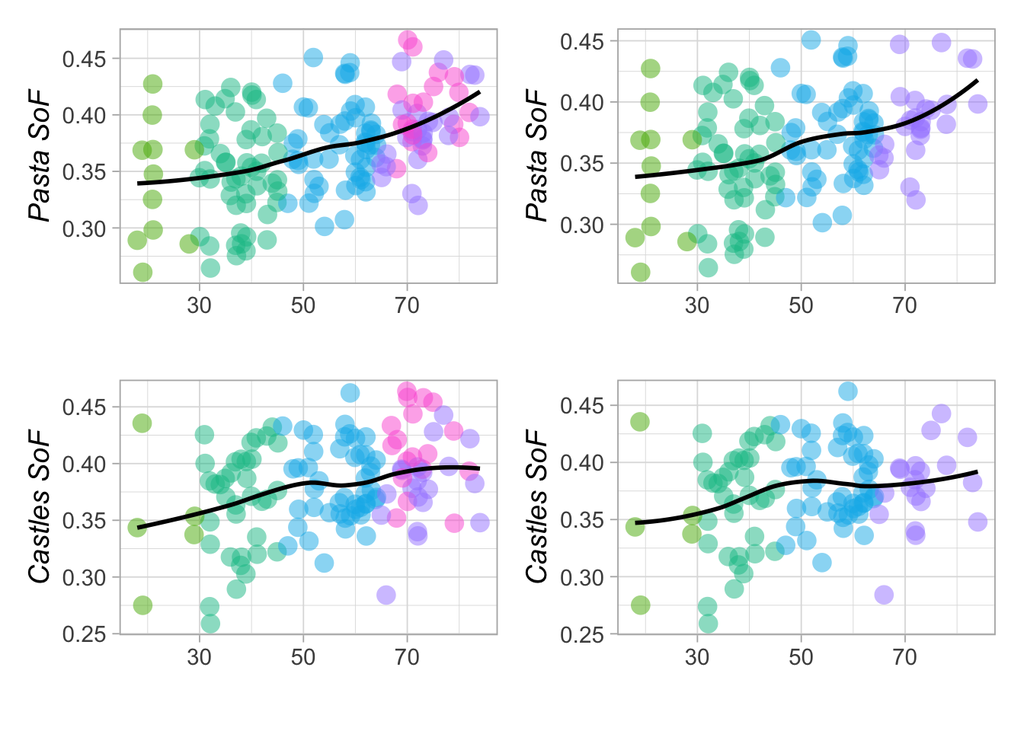

```r
# Create dataset for Pasta lesson only
cleandata_avg_PASTA <- cleandata_avg_all[cleandata_avg_all$lessonTitle == "Pasta",]

# Create SoF plot for Pasta lesson
pasta <- ggplot(cleandata_avg_PASTA, aes(x = age, y = MeanAlpha)) +
  geom_point(aes(color = category3, group = paired), alpha = 0.5, size = 4.5, stroke = 0, position = position_dodge(0.25)) +
  geom_smooth(method = 'loess', se = FALSE, color = 'black', size = 1) +  # Add loess trend line
  scale_color_manual(values = c("#54b300", "#00c094", "#02b7eb", "#a58aff", "#fb61d7")) +
  scale_fill_manual(values = c("#54b300", "#00c094", "#02b7eb", "#a58aff", "#fb61d7")) +
  xlab(" ") +
  ylab(expression(paste(italic("Pasta SoF")))) +
  labs(col = "Age Group", fill = "Age Group") +
  theme(legend.position = "hide")

# Remove impaired group from Pasta data
cleandata_avg_PASTA_noimp <- cleandata_avg_PASTA[!cleandata_avg_PASTA$category3 %in% c("Senior Impaired (65+)"),]

# Create SoF plot for Pasta lesson without impaired group
pasta_noimp <- ggplot(cleandata_avg_PASTA_noimp, aes(x = age, y = MeanAlpha)) +
  geom_point(aes(color = category3, group = paired), alpha = 0.5, size = 4.5, stroke = 0, position = position_dodge(0.25)) +
  geom_smooth(method = 'loess', se = FALSE, color = 'black', size = 1) +  # Add loess trend line
  scale_color_manual(values = c("#54b300", "#00c094", "#02b7eb", "#a58aff", "#fb61d7")) +
  scale_fill_manual(values = c("#54b300", "#00c094", "#02b7eb", "#a58aff", "#fb61d7")) +
  xlab(" ") +
  ylab(expression(paste(italic("Pasta SoF")))) +
  labs(col = "Age Group", fill = "Age Group") +
  theme(legend.position = "hide")

# Create dataset for Castles lesson only
cleandata_avg_CASTLES <- cleandata_avg_all[cleandata_avg_all$lessonTitle == "Castles",]

# Create SoF plot for Castles lesson
castles <- ggplot(cleandata_avg_CASTLES, aes(x = age, y = MeanAlpha)) +
  geom_point(aes(color = category3, group = paired), alpha = 0.5, size = 4.5, stroke = 0, position = position_dodge(0.25)) +
  geom_smooth(method = 'loess', se = FALSE, color = 'black', size = 1) +  # Add loess trend line
  scale_color_manual(values = c("#54b300", "#00c094", "#02b7eb", "#a58aff", "#fb61d7")) +
  scale_fill_manual(values = c("#54b300", "#00c094", "#02b7eb", "#a58aff", "#fb61d7")) +
  xlab(" ") +
  ylab(expression(paste(italic("Castles SoF")))) +
  labs(col = "Age Group", fill = "Age Group") +
  theme(legend.position = "hide")

# Remove impaired group from Castles data
cleandata_avg_CASTLES_noimp <- cleandata_avg_CASTLES[!cleandata_avg_CASTLES$category3 %in% c("Senior Impaired (65+)"),]

# Create SoF plot for Castles lesson without impaired group
castles_noimp <- ggplot(cleandata_avg_CASTLES_noimp, aes(x = age, y = MeanAlpha)) +
  geom_point(aes(color = category3, group = paired), alpha = 0.5, size = 4.5, stroke = 0, position = position_dodge(0.25)) +
  geom_smooth(method = 'loess', se = FALSE, color = 'black', size = 1) +  # Add loess trend line
  scale_color_manual(values = c("#54b300", "#00c094", "#02b7eb", "#a58aff", "#fb61d7")) +
  scale_fill_manual(values = c("#54b300", "#00c094", "#02b7eb", "#a58aff", "#fb61d7")) +
  xlab(" ") +
  ylab(expression(paste(italic("Castles SoF")))) +
  labs(col = "Age Group", fill = "Age Group") +
  theme(legend.position = "hide")

# Combine and save SoF plots into a grid for comparison
pasta_castles <- cowplot::plot_grid(pasta+pasta_noimp+castles+castles_noimp)
ggsave("figures/pasta_castles.png", pasta_castles)

pasta_castles
```

## LMER Report

```r
# Filter out rows with missing MeanAlpha values
complete_lmer <- filter(cleandata_avg_all, !is.na(MeanAlpha))

# Center the age variable by subtracting the mean age
complete_lmer <- complete_lmer %>%
  mutate(centeredAge = age - mean(age))

# Fixed effects model with centeredAge and random intercept for lessonTitle
model_fixed_age_random <- lmer(MeanAlpha ~ centeredAge + (1|lessonTitle), complete_lmer)

# Fixed effects model with category3 and centeredAge, random intercept for lessonTitle
model_fixed_cat_age_random <- lmer(MeanAlpha ~ category3 + centeredAge + (1|lessonTitle), complete_lmer)

# Fixed effects model with category3 and centeredAge, random intercepts for lessonTitle and userId
model_fixed_cat_age_random_user <- lmer(MeanAlpha ~ category3 + centeredAge + (1|lessonTitle) + (1|userId), complete_lmer)

# Mixed model with fixed effects and random slope for userId
model_fixed_cat_age_random_slope <- lmer(MeanAlpha ~ category3 + centeredAge + (1|lessonTitle) + (1 + centeredAge | userId), complete_lmer)

# Interaction model with category3 and centeredAge, random intercepts for lessonTitle and userId
model_interaction_cat_age_random <- lmer(MeanAlpha ~ category3 * centeredAge + (1|lessonTitle) + (1|userId), complete_lmer)
```

```r
# Use `anova` function to see if full model is better than base model
anova(model_fixed_age_random, model_fixed_cat_age_random, model_fixed_cat_age_random_user, model_fixed_cat_age_random_slope, model_interaction_cat_age_random) %>%
  xtable() %>%
  kable(digits=4) %>%
  kable_styling(bootstrap_options = c("striped", "hover"))
```

|  | npar | AIC | BIC | logLik | deviance | Chisq | Df | Pr(>Chisq) |
| --- | --- | --- | --- | --- | --- | --- | --- | --- |
| model_fixed_age_random | 3 | -9895.632 | -9877.534 | 4950.816 | -9901.632 | NA | NA | NA |
| model_fixed_cat_age_random | 9 | -11166.813 | -11112.519 | 5592.407 | -11184.813 | 1283.181 | 6 | 0 |
| model_fixed_cat_age_random_user | 10 | -12920.286 | -12859.960 | 6470.143 | -12940.286 | 1755.473 | 1 | 0 |
| model_interaction_cat_age_random | 10 | -12920.286 | -12859.960 | 6470.143 | -12940.286 | 0.000 | 0 | NA |
| model_fixed_cat_age_random_slope | 12 | -12916.286 | -12843.894 | 6470.143 | -12940.286 | 0.000 | 2 | 1 |

```r
# Table with all the model effects
model_interaction_cat_age_random %>%
  tidy() %>%
  kable() %>%
  kable_styling(bootstrap_options = c("hover", "striped"))
```

| effect | group | term | estimate | std.error | statistic | df | p.value |
| --- | --- | --- | --- | --- | --- | --- | --- |
| fixed | NA | (Intercept) | 0.3996337 | 0.0166837 | 23.9535226 | 107.5274 | 0.0000000 |
| fixed | NA | category3Adolescence (13-17) | -0.0429856 | 0.0254054 | -1.6919872 | 284.1093 | 0.0917448 |
| fixed | NA | category3Early Adulthood (18-29) | -0.0856334 | 0.0171030 | -5.0069154 | 113.6459 | 0.0000020 |
| fixed | NA | category3Middle Adulthood (30-45) | -0.0533606 | 0.0177384 | -3.0082012 | 129.6652 | 0.0031578 |
| fixed | NA | category3Mature Adulthood (46-64) | -0.0329027 | 0.0175528 | -1.8745012 | 124.6766 | 0.0632015 |
| fixed | NA | category3Senior Adulthood (65+) | -0.0301436 | 0.0178260 | -1.6909859 | 130.4243 | 0.0932278 |
| fixed | NA | category3Senior Impaired (65+) | 0.0128532 | 0.0178298 | 0.7208814 | 130.5346 | 0.4722715 |
| ran_pars | userId | sd__(Intercept) | 0.0308192 | NA | NA | NA | NA |
| ran_pars | lessonTitle | sd__(Intercept) | 0.0133273 | NA | NA | NA | NA |
| ran_pars | Residual | sd__Observation | 0.0262419 | NA | NA | NA | NA |

```r
# APA-style report
tab_model(model_interaction_cat_age_random)
```

|  | Mean Alpha |  |  |
| --- | --- | --- | --- |
| Predictors | Estimates | CI | p |
| (Intercept) | 0.40 | 0.37 – 0.43 | **<0.001** |
| category3Adolescence (13-17) | -0.04 | -0.09 – 0.01 | 0.091 |
| category3Early Adulthood (18-29) | -0.09 | -0.12 – -0.05 | **<0.001** |
| category3Middle Adulthood (30-45) | -0.05 | -0.09 – -0.02 | **0.003** |
| category3Mature Adulthood (46-64) | -0.03 | -0.07 – 0.00 | 0.061 |
| category3 [Senior Adulthood (65+)] | -0.03 | -0.07 – 0.00 | 0.091 |
| category3 [Senior Impaired (65+)] | 0.01 | -0.02 – 0.05 | 0.471 |
| Random Effects |  |  |  |
| σ<sup>2</sup> | 0.00 |  |  |
| τ<sub>00</sub> <sub>userId</sub> | 0.00 |  |  |
| τ<sub>00</sub> <sub>lessonTitle</sub> | 0.00 |  |  |
| ICC | 0.62 |  |  |
| N <sub>lessonTitle</sub> | 55 |  |  |
| N <sub>userId</sub> | 313 |  |  |
| Observations | 3080 |  |  |
| Marginal R<sup>2</sup> / Conditional R<sup>2</sup> | 0.384 / 0.766 |  |  |

## Model Summary Report

The model summary shows the results of a mixed-effects linear regression (lmer) that predicts “MeanAlpha” based on various categorical age groups (in the variable category3), as well as random intercepts for “lessonTitle” and “userId”.

```r
# Function to format p-values, handling missing values
format_p_value <- function(p_value) {
  if (is.na(p_value) || length(p_value) == 0) {
    return("NA")
  } else if (p_value < .001) {
    return("< .001")
  } else {
    return(sprintf("= %.3f", p_value))
  }
}

model_summary <- tidy(model_interaction_cat_age_random, conf.int = TRUE)

# Extract values for reporting
intercept <- model_summary %>% filter(term == "(Intercept)")
adolescence <- model_summary %>% filter(term == "category3Adolescence (13-17)")
early_adulthood <- model_summary %>% filter(term == "category3Early Adulthood (18-29)")
middle_adulthood <- model_summary %>% filter(term == "category3Middle Adulthood (30-45)")
mature_adulthood <- model_summary %>% filter(term == "category3Mature Adulthood (46-64)")
senior_adulthood <- model_summary %>% filter(term == "category3Senior Adulthood (65+)")
senior_impaired <- model_summary %>% filter(term == "category3Senior Impaired (65+)")


# Calculate R-squared values
r_squared_values <- r.squaredGLMM(model_interaction_cat_age_random)
marginal_r_squared <- round(r_squared_values[1], 3)
conditional_r_squared <- round(r_squared_values[2], 3)
```

## APA Style Report

```r
# Construct the APA-style report
adolescence_report <- if (adolescence$p.value < 0.05) {
  glue::glue("Adolescents (13-17) had a significant reduction in Mean Alpha, b = {round(adolescence$estimate, 2)}, 95% CI [{round(adolescence$conf.low, 2)}, {round(adolescence$conf.high, 2)}], p {format_p_value(adolescence$p.value)}.")
} else {
  glue::glue("Adolescents (13-17) had a non-significant reduction in Mean Alpha, b = {round(adolescence$estimate, 2)}, 95% CI [{round(adolescence$conf.low, 2)}, {round(adolescence$conf.high, 2)}], p {format_p_value(adolescence$p.value)}.")
}

early_adulthood_report <- if (early_adulthood$p.value < 0.05) {
  glue::glue("Early adulthood (18-29) had a significant reduction in Mean Alpha, b = {round(early_adulthood$estimate, 2)}, 95% CI [{round(early_adulthood$conf.low, 2)}, {round(early_adulthood$conf.high, 2)}], p {format_p_value(early_adulthood$p.value)}.")
} else {
  glue::glue("Early adulthood (18-29) had a non-significant reduction in Mean Alpha, b = {round(early_adulthood$estimate, 2)}, 95% CI [{round(early_adulthood$conf.low, 2)}, {round(early_adulthood$conf.high, 2)}], p {format_p_value(early_adulthood$p.value)}.")
}

middle_adulthood_report <- if (middle_adulthood$p.value < 0.05) {
  glue::glue("Middle adulthood (30-45) also showed a significant reduction in Mean Alpha, b = {round(middle_adulthood$estimate, 2)}, 95% CI [{round(middle_adulthood$conf.low, 2)}, {round(middle_adulthood$conf.high, 2)}], p {format_p_value(middle_adulthood$p.value)}.")
} else {
  glue::glue("Middle adulthood (30-45) had a non-significant reduction in Mean Alpha, b = {round(middle_adulthood$estimate, 2)}, 95% CI [{round(middle_adulthood$conf.low, 2)}, {round(middle_adulthood$conf.high, 2)}], p {format_p_value(middle_adulthood$p.value)}.")
}

mature_adulthood_report <- if (mature_adulthood$p.value < 0.05) {
  glue::glue("Mature adulthood (46-64) exhibited a significant reduction in Mean Alpha, b = {round(mature_adulthood$estimate, 2)}, 95% CI [{round(mature_adulthood$conf.low, 2)}, {round(mature_adulthood$conf.high, 2)}], p {format_p_value(mature_adulthood$p.value)}.")
} else if (mature_adulthood$p.value < 0.1) {
  glue::glue("Mature adulthood (46-64) exhibited a marginally significant reduction in Mean Alpha, b = {round(mature_adulthood$estimate, 2)}, 95% CI [{round(mature_adulthood$conf.low, 2)}, {round(mature_adulthood$conf.high, 2)}], p {format_p_value(mature_adulthood$p.value)}.")
} else {
  glue::glue("Mature adulthood (46-64) had a non-significant reduction in Mean Alpha, b = {round(mature_adulthood$estimate, 2)}, 95% CI [{round(mature_adulthood$conf.low, 2)}, {round(mature_adulthood$conf.high, 2)}], p {format_p_value(mature_adulthood$p.value)}.")
}

senior_adulthood_report <- if (senior_adulthood$p.value < 0.05) {
  glue::glue("For the senior age groups, Senior Adulthood (65+) showed a significant difference, b = {round(senior_adulthood$estimate, 2)}, 95% CI [{round(senior_adulthood$conf.low, 2)}, {round(senior_adulthood$conf.high, 2)}], p {format_p_value(senior_adulthood$p.value)}.")
} else {
  glue::glue("For the senior age groups, Senior Adulthood (65+) showed a non-significant difference, b = {round(senior_adulthood$estimate, 2)}, 95% CI [{round(senior_adulthood$conf.low, 2)}, {round(senior_adulthood$conf.high, 2)}], p {format_p_value(senior_adulthood$p.value)}.")
}

senior_impaired_report <- if (senior_impaired$p.value < 0.05) {
  glue::glue("Senior Impaired (65+) also showed a significant difference, b = {round(senior_impaired$estimate, 2)}, 95% CI [{round(senior_impaired$conf.low, 2)}, {round(senior_impaired$conf.high, 2)}], p {format_p_value(senior_impaired$p.value)}.")
} else {
  glue::glue("Senior Impaired (65+) showed a non-significant difference, b = {round(senior_impaired$estimate, 2)}, 95% CI [{round(senior_impaired$conf.low, 2)}, {round(senior_impaired$conf.high, 2)}], p {format_p_value(senior_impaired$p.value)}.")
}

# Combine all sections into the final report
apa_report <- glue::glue("
The linear mixed-effects model predicting Mean Alpha yielded a significant intercept, b = {round(intercept$estimate, 2)}, 95% CI [{round(intercept$conf.low, 2)}, {round(intercept$conf.high, 2)}], p {format_p_value(intercept$p.value)}.

For age categories:

{adolescence_report}

{early_adulthood_report}

{middle_adulthood_report}

{mature_adulthood_report}

{senior_adulthood_report}

{senior_impaired_report}

The model explains {round(r.squaredGLMM(model_interaction_cat_age_random)[1], 3)} of the variance in Mean Alpha based on the fixed effects (R²_Marginal), and {round(r.squaredGLMM(model_interaction_cat_age_random)[2], 3)} when both fixed and random effects are considered (R²_Conditional).
")

# Print the APA report
#cat(apa_report)
```

[output not shown]

The linear mixed-effects model predicting Mean Alpha yielded a significant intercept, b = 0.4, 95% CI [0.37, 0.43], p < .001.

For age categories:

Adolescents (13-17) had a non-significant reduction in Mean Alpha, b = -0.04, 95% CI [-0.09, 0.01], p = 0.092.

Early adulthood (18-29) had a significant reduction in Mean Alpha, b = -0.09, 95% CI [-0.12, -0.05], p < .001.

Middle adulthood (30-45) also showed a significant reduction in Mean Alpha, b = -0.05, 95% CI [-0.09, -0.02], p = 0.003.

Mature adulthood (46-64) exhibited a marginally significant reduction in Mean Alpha, b = -0.03, 95% CI [-0.07, 0], p = 0.063.

Senior Impaired (65+) showed a non-significant difference, b = 0.01, 95% CI [-0.02, 0.05], p = 0.472.

The model explains 0.384 of the variance in Mean Alpha based on the fixed effects (R²_Marginal), and 0.766 when both fixed and random effects are considered (R²_Conditional).